# 0_calculus_tutorial

1. Introduction
2. Limits, Derivatives, & Integrals
3. Series
4. Parametric Equations & Polar Coordinates
5. Vectors & Vector Calculus

# 1 - Introduction

I distinctly remember my very first math class as an undergrad. I was majoring in Mechanical Engineering with no background in Computer Science or any form of programming. I was a bit of a math wiz growing up, but to be honest, I very naively thought that I could get away with just coasting through school and a career without worrying about developing any real computer skills. However, after introducing the Calc 2 course that first day, my professor acknowledged that the school had recently invested in campus-wide access to [MATLAB](https://www.mathworks.com/products/matlab.html). He explained that learning how to use it would not only be helpful as a resource to check homework answers, but also a game-changer for any students hoping for a career in engineering. This sparked my interest, and eventually led me to altogether change my degree to Applied Mathematics and Computer Science. Now, I have a career as a Data Scientist.

My point isn't that every student taking a college math class needs to learn MATLAB. However, looking back I wish I could have understood that the real power of mathematics doesn't come with a paper and pencil. Computers are unbelievably powerful machines, capable of solving problems with speed and precision impossible to any person. Of course, this doesn't mean that people do not need to learn math. The potential of mathematics is reached when a person who understands the principles and theories combines their knowledge with the capabilities of modern computers. This is where education systems often fall short - they exclusively teach math without teaching students how to apply their knowledge programmatically.

### **The Purpose of this Blog**

The purpose of this blog is not to teach programming. There are already countless resources readily available for those that are genuinely interested in learning to program. Instead, this blog is meant for students who want to use computers to help them with their math homework. This is how I was first introduced to programming. When I began, I didn't really understand what was actually happening in the background. But by simply typing out the problem I could make sure that my work was correct. To me, this was a priceless resource. Furthermore, it was what inspired me to seek out a deeper understanding of computer science and actually apply the math that I was learning. I hope that by writing this blog, I not only help students to get the correct answers on their assignments, but also inspire them to dig deeper.

My blog is also not meant to teach math, although some principles might be explained briefly. Rather, it is meant to teach students how to use programming to solve math problems. I will primarliy be focusing my content on solving calculus problems. However, mathematics is one of those things that builds upon prior knowledge. For students studying Algebra or Trigonometry, I am sure that some of my blogposts will cover many of the concepts taught in those courses.

### **Introduction to Python and Sympy**

Although many programming languages exist, one of the most popular for scientific programming is [Python](https://wiki.python.org/moin/BeginnersGuide/Overview). One of the greatest benefits of Python is that it is all Open-Source, meaning that it is free to use. Furthermore, anyone can create add-on libraries that are free to install. Throughout my blog, I will primarily be relying on a Python package called [SymPy](https://www.sympy.org/en/index.html). For each article, I will give an explanation of what I am doing. But it will be easiest if I start out this blog series with an introduction to Python and SymPy, since I am assuming that my readers have little or no background in programming.

Python can either be run locally on your computer or on the cloud. If you are running Python locally, I recommend using [Anaconda](https://docs.anaconda.com/anaconda/install/index.html). However, the easiest solution - especially for a beginner - would be to use a cloud-based platform. [Google Colab](https://research.google.com/colaboratory/faq.html), a free cloud-based platform hosted by Google. It is formatted as a "Notebook", which is basically a more user-friendly view for coding in Python. Colab Notebooks are saved in Google Drive, so the only requirement is that you first obtain a Google Account. To create a new Colab Notebook or to view some of the examples provided by Google, click on the following link:

https://colab.research.google.com/?utm_source=scs-index

Within your notebook, you can add individual "cells". Each of the code cells can be executed separately by either clicking the "play" button, or by pressing **CTRL**+**ENTER** / **CMD**+**ENTER** and display each of their respective results below them. There are also text cells available for titles, notes, etc. Additional cells can easily be inserted using the *+Code* or *+Text* buttons at the top.

To begin, we will need to import any additional libraries that will be used. In our case, that's only the SymPy library. Importing a library in python is pretty straight-forwarward. You simply need to use the `import` command. In general, libraries come with multiple functions/methods that can be imported individually. This is typically good practice. But in our case we are just going to import the full functionality of the SymPy library. This is done with by running `from sympy import *`.

```python
from sympy import *
```

From here, it isn't too difficult. To create variables, you use what are referred to in SymPy as `symbols`. As an example, let's say you want to use the variable $x$ in your equation. First, you must create $x$ as a variable. This is done with the following line of code:

```python
# create a variable "x"
x = symbols('x')
```

The first thing I would like to note is the first line of code, `# create a variable "x"`. This line is not necessary, just used as a "comment" for whomever is reading the code. Any line beginning with `#` in Python is considered a comment. A comment is often used a reference to explain what a section of code is doing.

The second line is the important one: `x = symbols('x')`. If you recall, I mentioned that SymPy uses `symbols` as a function to define variables. In this line, it is declared that $x$ is a symbol, denoted by the `'x'` argument within the `symbol` function's brackets. `'x'` is what is referred to in the "computer world" as a *string*, or a data-type denoted by Unicode characters. If that's confusing to you, no need to worry. In less tech-savvy terms, a string is literally just some data stored in a "string" of characters. Anything within quotes in pyton is considered a string (they can be single or double quotes).

To recap, to create a variable we need to *declare* what it will be. It doesn't need to be $x$, it can be almost anything. Let's try using *y* instead:

```python
y = symbols('y')
print(y)
```

```
y
```

This time, I added an extra line of code: `print(y)`. What is this for? Well you might have noticed that after running this cell, it literally "printed" $y$. The `print()` function is used to display whatever argument is put inside of its brackets. In this case, we created the variable (symbol) `y`, and then printed it.

Now, to simplify things I will show how to create multiple variables in just one line of code:

```python
# create multiple variables
a, b, c = symbols('a b c')
```

Notice that each of the declared variables are separated by a comma, and the variables listed within the string (the parameter for the `symbols()` function) are separated by a space. As long as this syntax is followed (with the variable names and order matching), you can create as many variables as you need!

For a shortcut to create some of the most common symbols used (i.e. $x$, $y$, $z$, $t$, etc.), simply use the `init_session()` function at the beginning of your session. It will `import *`, create common symbols, and call `init_printing()`.

```python
# to create basic symbols and common functionality (to hide the dialogue, use the argument "quiet=True")
init_session()
```

```
IPython console for SymPy 1.8 (Python 3.9.7-64-bit) (ground types: python)

These commands were executed:
>>> from __future__ import division
>>> from sympy import *
>>> x, y, z, t = symbols('x y z t')
>>> k, m, n = symbols('k m n', integer=True)
>>> f, g, h = symbols('f g h', cls=Function)
>>> init_printing()

Documentation can be found at https://docs.sympy.org/1.8/
```

`init_printing()` lets you print out your python code in actual mathematical notation. It is not necessarily something you need, but can be helpful at times depending on what you need. I have created a simple example below:

```python
# latex print after "init_printing()" is initiated using init_session()

Integral((1/x)**3, x)
```

$\displaystyle \int \frac{1}{x^{3}}\, dx$

Moving forward, assume that each new script includes both `from sympy import *` and `init_session()` at the beginning.

From here, creating, solving, and plotting actual equations is pretty straight-forward. Before jumping into any actual calculus, I will give a brief demonstration of plotting with SymPy. Then, I will just explain any other new concepts as they come up.

### **Plotting in Sympy**

One of the biggest challenges in math, especially as it becomes more and more complex, is visualizing what is going on. With that being said, I thought it would be helpful to do one more "introductory" article before diving into some real math. Again, some of these things will be expounded upon later on, but I wanted to at least give some background on how to plot so that it I don't have to explain it too deeply later on.

To plot you will be using the `plotting.plot()` function. By default, SymPy plots use the `matplotlib` library - one of them most popular Python plotting libraries - in the backend. But SymPy plotting is set up so that it is easy to integrate (no pun intended) calculus problems. If you are coding in a notebook, I would recommend using the `%matplotlib inline` [magic](https://ipython.readthedocs.io/en/stable/interactive/tutorial.html#magics-explained) function at the beginning of your script to automatically print the plot in the notebook.

When calling the function, simply put the calculation that you wish to plot into the paranthases. We will also include the `line_color` argument to specify the color:

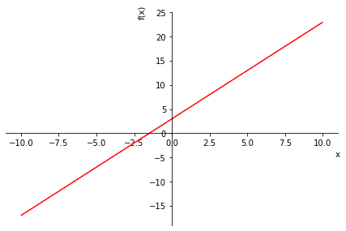

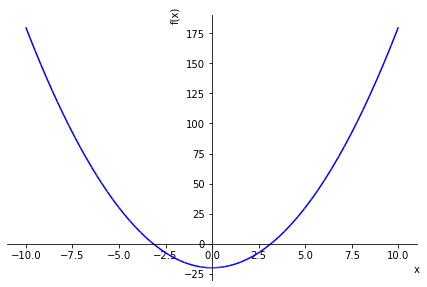

```python
%matplotlib inline

p1 = plotting.plot(3 + 2*x, line_color='red', show=True)
p2 = plotting.plot(2*x**2 - 20, line_color='blue', show=True)
```

To combine two plots into one, just use the `extend` method as follows:

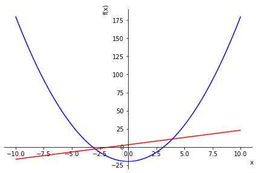

```python
p1.extend(p2)
p1.show()
```

3D plotting is a little more complex. Instead of calling `plotting.plot()`, instead call the `plotting.plot3d()` function. In addition to the calculation to be plotted, it is also necessary to specify the $x$ and $y$ limits of the plot. This is done through tuples of the following format:

`(variable, variable minimum, variable maximum)`

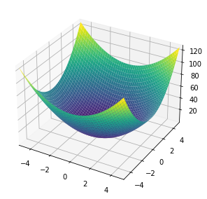

```python
p3 = plotting.plot3d(2*x**2 + 3*y**2, (x, -5, 5), (y, -5, 5))
```

*Full SymPy Tutorial:* https://docs.sympy.org/latest/tutorial/index.html

*Addional documentation can be found at the official SymPy website:* https://docs.sympy.org/latest/modules/plotting.html

# 2 - Limits, Derivatives, & Integrals

### **Limits**

Sympy comes with its own `limit` function, which makes computing limits pretty straightforward. I will print out a series of limit problems, and then demonstrate how to use sympy to solve each of them:

**a.** $\lim_{x \to 3} f(x)$ where $f(x) = x^2$

**b.** $\lim_{x \to 0} g(x)$ where $g(x) = \frac{\lvert x \rvert }{x}$

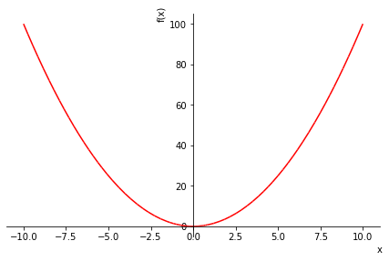

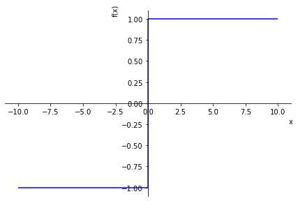

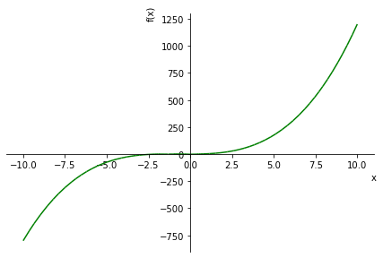

```python
f_x = x**2
g_x = Abs(x)/x
h_x = x**3 + 2*x**2

plot_a = plotting.plot(f_x, line_color='red')
plot_b = plotting.plot(g_x, line_color='blue')
plot_c = plotting.plot(h_x, line_color='green')
```

To solve $\lim_{x \to 3} f(x)$, use the sympy `limit` function using the following format/parameters:

`limit(function, symbol, limit)`

```python
limit(f_x, x, 3)
```

$\displaystyle 9$

Easy! Unfortunately, SymPy calculates limits using a series expansion. Because this is only an approximation, functions that contain discontinuities or domain constraints are often calculated incorrectly. For example, the limit as $g(x)$ approaches zero has no solution. However, Sympy approximates the limit to be either 1 or -1:

```python
limit(g_x, x, 0)
```

$\displaystyle 1$

Luckily, [workarounds](https://medium.com/swlh/fixing-sympys-limit-calculation-flaws-5b46440f97c1) exist that make taking limits of this nature doable. Creating a custom [function](https://docs.python.org/3/tutorial/controlflow.html#defining-functions) that takes the limit at points close to the original "approaching" point makes this a simple process.

```python
def lim(func, variable, approaching, approachFrom='None'):
    """
    Custom limit function that handles discontinuities
    param func: function that you are taking the limit of
    param variable: variable in the function
    param approaching: the number your are approaching in the limit
    param approachFrom: direction approaching from; either "-", "+", or "None"
    """
    # If the `approachFrom` direction is negative:
    if approachFrom=='-':
        # substitute the original `approaching` parameter with a number slightly to the left
        if func.subs(variable, approaching - 1e-6).is_real:
            return sympy.limit(func, variable, approaching, approachFrom)
        else:
            print('Limit does not exist')
    # If the `approachFrom` direction is positive:
    elif approachFrom == '+':
        # substitute the original `approaching` parameter with a number slightly to the right
        if func.subs(variable, approaching + 1e-6).is_real:
            return sumpy.limit(func, variable, approaching, approachFrom)
        else:
            print('Limit does not exist')
    # If the `approachFrom` direction is neither, test both and subtruct:
    else:
        # substitute the original `approaching` parameter with a number slightly to the left and to the right, then subtract
        leftApprox = func.subs(variable, approaching - 1e-6)
        rightApprox = func.subs(variable, approaching + 1e-6)
        if Abs(leftApprox-rightApprox) < 0.1:
            return sympy.limit(func, variable, approaching)
        else:
            print('Limit does not exist')

lim(g_x, x, 0)
```

```
Limit does not exist
```

If the limit is infinity, this can easily be specified using double "o". Evaluating the limit on only one side can also be done through an additional argument `'+'` or `'-'`:

```python
lim(h_x, x, oo, '+')
```

```
Limit does not exist
```